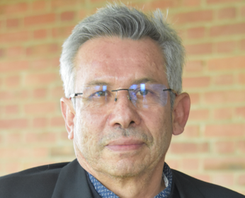

Un cordial saludo, trabajo en la [Escuela Colombiana de Ingeniería](https://www.escuelaing.edu.co/es/) en el [Departamento de Matemáticas](https://www.escuelaing.edu.co/es/programas/matematicas/). Soy Ingeniero de Sistemas y Matemático de la [Universidad de los Andes](https://uniandes.edu.co/), con Maestría en Ingeniería de Sistemas de la misma Universidad.

## Áreas de Interés

Inteligencia Artificial Generativa [CursoChatGpt Octubre 2024](https://jamelende.github.io/PaginasWeb/EdCont2024/P%C3%A1ginaWebChatGpt20242.html)

Machine Learning y Deep learning [DiplomadoIA Noviembre 2024](https://jamelende.github.io/PaginasWeb/P%C3%A1ginasWebCID/P%C3%A1ginaWebIA20242.html)

Modelación y Análisis de Redes ([Network Science](http://networksciencebook.com/)).

Modelación Basada en Agentes ([NetLogo](https://ccl.northwestern.edu/netlogo/)).

Modelación de Sistemas Complejos (AnyLogic)

Educación Matemática con Tecnología ([GeoGebra](https://www.geogebra.org/))

## Títulos

Matematico Universidad de los Andes 1978-1984. [Diploma](http://profesores.is.escuelaing.edu.co/~amelendez/HojaDeVida/Anexos/2.1%20Diplomas/DiplomaPregradoMat.pdf)

Ingeniero De Sistemas y Computación Universidad de los Andes 1978- 1984. [Diploma](http://profesores.is.escuelaing.edu.co/~amelendez/HojaDeVida/Anexos/2.1%20Diplomas/DiplomaPregradoSist.pdf)

Magister Ing de Sistemas y Computación Universidad de los Andes 1994-1996. [Diploma](http://profesores.is.escuelaing.edu.co/~amelendez/HojaDeVida/Anexos/2.2%20Diplomas%20Posgrado/DiplomaMagister.pdf)

Precálculo (Práctica I) 1983

Asesor: [Dr Xavier Caicedo](https://math.uniandes.edu.co/webxcaicedo/) , Universidad de los Andes Matemáticas

Matemáticas Básicas para Ciencias Sociales (03) 1984

Asesor: [Mat. Leonardo Venegas](https://www.youtube.com/watch?v=qhIh7Ouzxeo), Universidad de los Andes Matemáticas

### Tesis Pregrado Sistemas

Trabajo de Tesis de Pregrado (1984): “Ajedrez por Computador”

Asesor: [Dr Rodrigo Cardoso](https://profesores.virtual.uniandes.edu.co/rcardoso/es/inicio/), Universidad de los Andes Bogotá

### Tesis Magister Sistemas

Trabajo de Tesis de Magister (1994): “Plan Estratégico para el Centro de Estudios en Informática Educativa

de la Escuela Colombiana de Ingeniería”

Asesor: [Dr Alvaro Galvis Panqueva](https://sites.google.com/site/galvaro50/), Concord Consortium Estados Unidos

Jurados: Dr Roberto Zarama, Ingeniería Industrial, Universidad de los Andes Bogotá

Dr Humberto Serna, Administración, Universidad de los Andes Bogotá

Dr Ernesto Lleras, Ingeniería de Sistemas Universidad de los Andes Bogotá

## Cronología

[2026-2024](https://jamelende.github.io/PaginasWeb/HojadeVida/Cronologia2026-2024.html)

[2017-2014](http://profesores.is.escuelaing.edu.co/~amelendez/HojaDeVida/Cronologia2017-2014.html)

[2013-2010](http://profesores.is.escuelaing.edu.co/~amelendez/HojaDeVida/Cronologia2013-2010.html)

[Ántes de 2010](http://profesores.is.escuelaing.edu.co/~amelendez/HojaDeVida/CronologiaAntes2010.html)

## Visitas

[Internacionales](http://profesores.is.escuelaing.edu.co/~amelendez/HojaDeVida/VisitasInternacionales.html)

[Alta Calidad](http://profesores.is.escuelaing.edu.co/~amelendez/HojaDeVida/VisitasAltaCalidad.html)

[Registro Calificado](http://profesores.is.escuelaing.edu.co/~amelendez/HojaDeVida/VisitasRegistro.html)

## Capacitación

#### 2021

Curso Network Science and Machine Learning on Graphs  
Curso Internacional de Verano ECI  
6 al 12 de julio de 2021  
Prof: [Leonardo Gutierrez Gómez](https://www.linkedin.com/in/leonardo-guti%C3%A9rrez-g%C3%B3mez-b2211320/?originalSubdomain=lu)

[Certificado](https://www.dropbox.com/s/kpydwkmlkbqfxe9/Jorge%20Alfonso%20Mel%C3%A9ndez%20Acu%C3%B1a%20-%20Network%20science%20and%20machine%20learning%20on%20graphs.pdf?dl=1)

#### 2018

Curso MOOC “Introduction to Agent Based Modelling” profesor William Rand Julio-Octubre de 2018.

[Certificado](http://profesores.is.escuelaing.edu.co/~amelendez/HojaDeVida/Anexos/2.3%20Cursos%20Complementarios/RandCurso.PNG)

#### 2013

Mayo: Curso Introduction to Complexity Santafé Institute, Prof Melanie Mitchell.

[Certificado](http://profesores.is.escuelaing.edu.co/~amelendez/HojaDeVida/Anexos/2.3%20Cursos%20Complementarios/Complexity.jpeg)

#### 2003

Moderación de Ambientes Virtuales de Aprendizaje (MAIA), Ene-Abr 2003, Concord Consortium

#### 2002

Creación de Ambientes Virtuales de Aprendizaje (CAVA) Sept-Dic 2002,Concord Consortium.

[Certificado](http://profesores.is.escuelaing.edu.co/~amelendez/HojaDeVida/Anexos/2.3%20Cursos%20Complementarios/DiplomaCAVA.pdf)

#### 1987

Seminario de Programación Funcional , Universidad de los Andes 1987.

## Docencia

[Docencia Escuela](http://profesores.is.escuelaing.edu.co/~amelendez/HojaDeVida/DocenciaEscuela.html)

[Docencia Otras Universidades](http://profesores.is.escuelaing.edu.co/~amelendez/HojaDeVida/DocenciaOtras.html)

## Publicaciones

[Libros](http://profesores.is.escuelaing.edu.co/~amelendez/HojaDeVida/Libros.html)

[Artículos de Investigación](http://profesores.is.escuelaing.edu.co/~amelendez/HojaDeVida/Art%C3%ADculosInv.html)

## Proyectos

[Proyectos de Investigación](http://profesores.is.escuelaing.edu.co/~amelendez/HojaDeVida/ProyectosInv.html)

[Proyectos y Propuestas](http://profesores.is.escuelaing.edu.co/~amelendez/HojaDeVida/ProyectosyPropuestas.html)

[Proyectos de Grado](http://profesores.is.escuelaing.edu.co/~amelendez/HojaDeVida/ProyectosDeGrado.html)

## Otros

[Seminarios](http://profesores.is.escuelaing.edu.co/~amelendez/HojaDeVida/Seminarios.html)

[Conferencias](http://profesores.is.escuelaing.edu.co/~amelendez/HojaDeVida/Conferencias.html)

[Herramientas Tecnológicas](http://profesores.is.escuelaing.edu.co/~amelendez/HojaDeVida/HerramientasTecnol%C3%B3gicas.html)

[Premios](http://profesores.is.escuelaing.edu.co/~amelendez/HojaDeVida/Premios.html)

[Jurado](http://profesores.is.escuelaing.edu.co/~amelendez/HojaDeVida/Jurado.html)

[Información de Contacto](http://profesores.is.escuelaing.edu.co/~amelendez/HojaDeVida/InfAdicional.html)